# fucus productivity

Lydia White

2025-05-24

## Set up our environment

### Load libraries

First we load libraries (which you should already have installed).

```r
library(tidyverse)
library(googlesheets4)
```

### Import data

```r
gs4_deauth()
#productivity <- read_sheet("1AyJXPaJZMl1a4vogToBIMSoPDGY2wBq8K3k8g9EptRc", sheet = "fucus_productivity_summary") #2025

productivity <- read_sheet("1STH7IQobfCN5dumGnuSGqDiIoqHk1IkAUg3TTRu0pVc", sheet = "fucus_productivity_summary") #2023
```

## Visualise differences in NPP

Visualise with boxplot of NPP and CR and GPP, per g of fucus for different sites. We can make less work for ourselves and plot all the data at once, but we have to reformat the data into long format first.

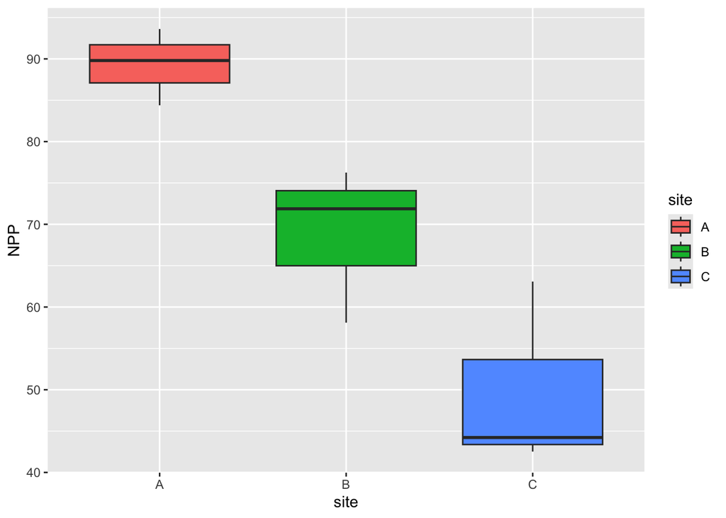

```r
ggplot(productivity, aes(x=site, y= NPP, fill = site))+
  geom_boxplot()
```

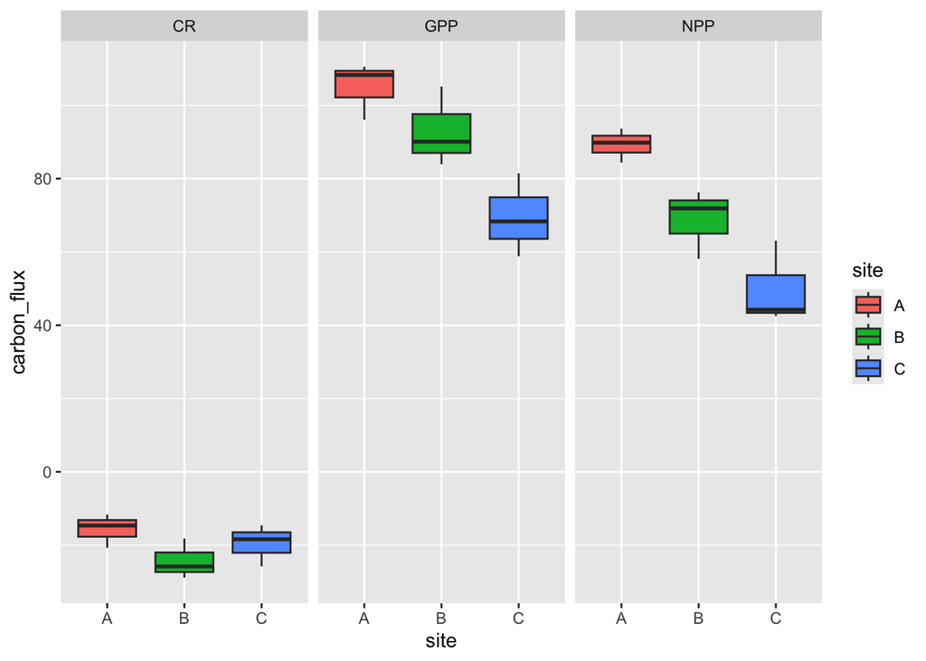

```r
productivity_long <- productivity %>% pivot_longer(cols = c("NPP", "CR", "GPP"), names_to = "metabolism", values_to = "carbon_flux")

ggplot(productivity_long, aes(x=site, y= carbon_flux, fill = site))+
  geom_boxplot() +
  facet_wrap(~metabolism)
```

We can tidy up the plot a bit, we 1) edit the y axis label and 2) remove the legend

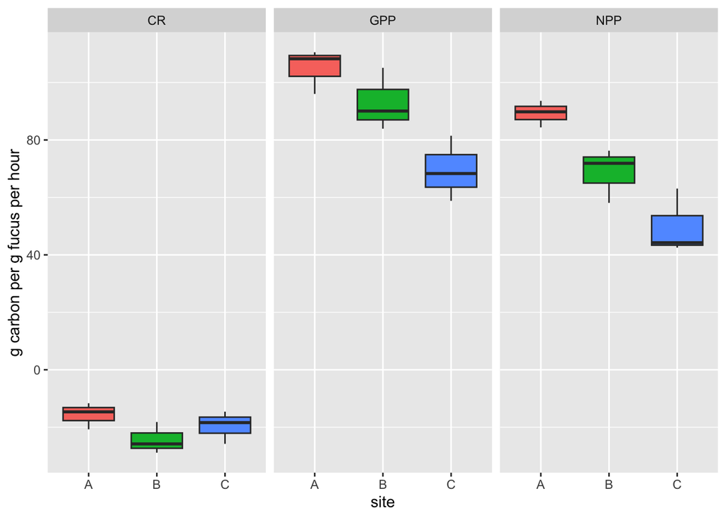

```r
ggplot(productivity_long, aes(x=site, y= carbon_flux, fill = site))+
  geom_boxplot() +
  facet_wrap(~metabolism) +
  ylab("g carbon per g fucus per hour") + # adds nice axis title
  theme(legend.position="none")
```

## Test differences with models

Lets explore these differences with statistical models, we can use one-way ANOVA to test if carbon fluxes significantly differ between sites

```r
anova1 <- aov(NPP ~ site, data = productivity)
summary(anova1)
```

```
##             Df Sum Sq Mean Sq F value Pr(>F)
## site         2 2321.2  1160.6   14.43 0.0051 **
## Residuals    6  482.6    80.4
## ---
## Signif. codes:  0 '***' 0.001 '**' 0.01 '*' 0.05 '.' 0.1 ' ' 1
```

### Checking assumptions of your model

The ANOVA test assumes that, the residuals from the model are normally distributed and the variance across groups are homogeneous (i.e. similar). We can check that with some diagnostic plots.

#### Homogeneity of variances

The residuals versus fits plot can be used to check the homogeneity of variances, the line. shoud be approximately straight

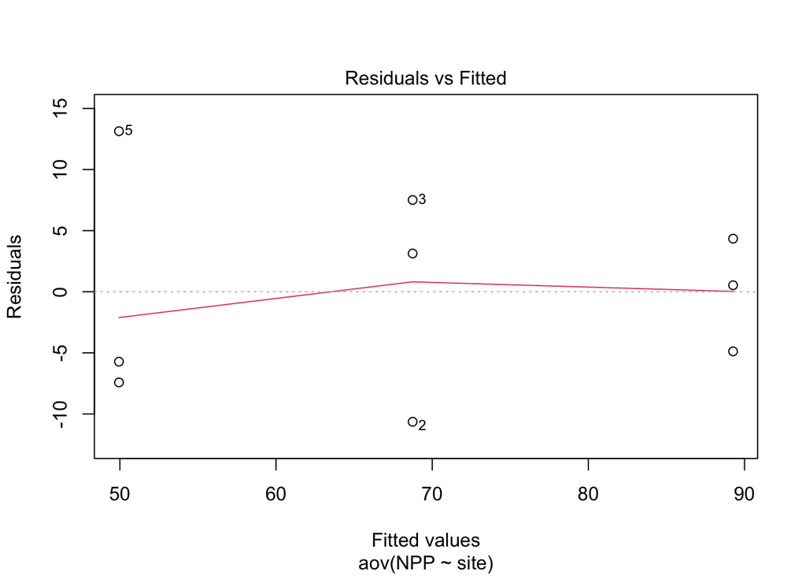

```r
plot(anova1, 1)
```

It’s also possible to use Levene’s test to check the homogeneity of variances. p < 0.05 means that they are not homogeneous.

```r
car::leveneTest(NPP ~ site, data = productivity)
```

```
## Levene's Test for Homogeneity of Variance (center = median)
##       Df F value Pr(>F)
## group  2  0.2147 0.8127
##        6
```

#### Normally distributed residuals

The normal probability plot of residuals is used to check the assumption that the residuals are normally distributed. It should approximately follow a straight line.

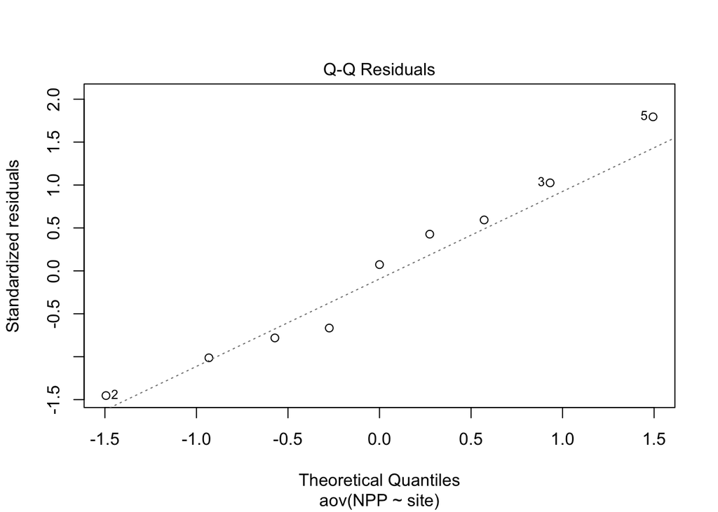

```r
plot(anova1, 2)
```

It’s also possible to use shapiro wilk test to check if the residuals are normally distributed. p < 0.05 means that they are not normally distributed.

```r
shapiro.test(rstandard(anova1))
```

```
##
##  Shapiro-Wilk normality test
##
## data:  rstandard(anova1)
## W = 0.966, p-value = 0.8585
```

In one-way ANOVA test, a significant p-value indicates that some of the group means are different, but we don’t know which pairs of groups are different. It’s possible to perform multiple pairwise-comparison, to determine if the mean difference between specific pairs of group are statistically significant.

```r
TukeyHSD(anova1)
```

```
##   Tukey multiple comparisons of means
##     95% family-wise confidence level
##
## Fit: aov(formula = NPP ~ site, data = productivity)
##
## $site
##          diff       lwr        upr     p adj
## B-A -20.52085 -42.98780   1.946102 0.0695965
## C-A -39.32541 -61.79236 -16.858460 0.0041194
## C-B -18.80456 -41.27151   3.662388 0.0936028
```

### What if assumptions are not met?

Note that, a non-parametric alternative to one-way ANOVA is Kruskal-Wallis rank sum test, which can be used when ANOVA assumptions are not met.

```r
kruskal.test(NPP ~ site, data = productivity)
```

```
##
##  Kruskal-Wallis rank sum test
##
## data:  NPP by site
## Kruskal-Wallis chi-squared = 6.4889, df = 2, p-value = 0.03899
```

## Differences in CR and GPP between sites

You could also carry out ANOVAs on the other parameters, to see if CR and GPP differ between sites.

```r
# write scripts here (copy and paste from above and change variable names)
```